# Lab 9: Markov Chains

STAT 536 — Statistical Computing (solutions)

Author

Soumojit Das

Published

Fall 2026

# Setup

Figure labels are typeset by LaTeX. `tikz_png()` draws a ggplot through `tikzDevice`, compiles it with `pdflatex`, and returns a PNG. It needs a LaTeX installation (TinyTeX is enough) and installs `tikzDevice`, `pdftools`, and `png` on first use. Both problems use `effectiveSize()` from the `coda` package, which the setup chunk installs if it is missing.

```r
library(ggplot2)
library(patchwork)
if (!requireNamespace("coda", quietly = TRUE)) install.packages("coda")
set.seed(536)
theme_set(theme_bw(base_size = 14))

pal <- c(red = "#D62828", blue = "#2E86AB", green = "#06A77D",
         orange = "#F77F00", dark = "#023047", grey = "#6a6a6a")

find_pdflatex <- function() {
  cand <- c(Sys.which("pdflatex"),
            path.expand("~/Library/TinyTeX/bin/universal-darwin/pdflatex"),
            file.path(Sys.getenv("APPDATA"), "TinyTeX/bin/windows/pdflatex.exe"),
            path.expand("~/.TinyTeX/bin/x86_64-linux/pdflatex"))
  cand <- cand[nzchar(cand) & file.exists(cand)]
  if (!length(cand)) stop("pdflatex not found; install TinyTeX with tinytex::install_tinytex()")
  cand[[1]]
}

tikz_png <- function(p, png_file, width = 9, height = 5, dpi = 150) {
  for (pkg in c("tikzDevice", "pdftools", "png"))
    if (!requireNamespace(pkg, quietly = TRUE)) install.packages(pkg)
  options(tikzLatex = find_pdflatex(),
          tikzDocumentDeclaration = r"(\documentclass[10pt]{article})",
          tikzLatexPackages = c(r"(\usepackage{tikz})",
                                r"(\usepackage[active,tightpage,psfixbb]{preview})",
                                r"(\PreviewEnvironment{pgfpicture})",
                                r"(\setlength\PreviewBorder{0pt})",
                                r"(\usepackage[T1]{fontenc})", r"(\usepackage{lmodern})",
                                r"(\usepackage{amsmath})"))
  work <- file.path(tempdir(), "tikz_png"); dir.create(work, showWarnings = FALSE)
  tex <- file.path(work, "fig.tex"); pdf <- file.path(work, "fig.pdf")
  tikzDevice::tikz(tex, width = width, height = height, standAlone = TRUE)
  print(p); dev.off()
  ok <- system2(getOption("tikzLatex"),
                c("-interaction=batchmode", "-halt-on-error",
                  paste0("-output-directory=", shQuote(work)), shQuote(tex)),
                stdout = FALSE, stderr = FALSE)
  if (ok != 0 || !file.exists(pdf)) stop("pdflatex failed; see ", file.path(work, "fig.log"))
  dir.create(dirname(png_file), recursive = TRUE, showWarnings = FALSE)
  png::writePNG(pdftools::pdf_render_page(pdf, page = 1, dpi = dpi), png_file)
  png_file
}

# tick labels in math mode, so minus signs and decimals are set by LaTeX
tex_num <- function(v) ifelse(is.na(v), NA,
  paste0("$", format(v, scientific = FALSE, drop0trailing = TRUE, trim = TRUE), "$"))
tex_theme <- theme(text = element_text(size = 17), plot.title = element_text(hjust = 0.5),
                   legend.position = "top", legend.key.width = unit(1.2, "cm"))
# whole-number ticks for a time axis
int_breaks <- function(lim) unique(round(pretty(lim)))
```

# Notation

The lab uses these symbols.

| Symbol | Meaning |
| --- | --- |
| $X_t$ | the state at time $t = 0, 1, 2, \ldots$ |
| $N$ | the chain length |
| $\pi$ | the stationary distribution |
| $\pi(x)$ | the stationary density, on a continuous state space |
| $\bar h_N$ | the time average $\frac1N\sum_{t=1}^N h(X_t)$ |
| $\sigma_h^2$ | the variance $\Var_\pi(h(X))$ |
| $\rho_k$ | the autocorrelation at lag $k$ |
| $\kappa$ | the inflation factor $1 + 2\sum_{k \ge 1}\rho_k$ |
| $q(y \mid x)$, $Y$ | the proposal density and the proposed value |
| $\alpha(x, y)$ | the acceptance probability |

Every problem ends with a **Report** list. Interpretation references the specific values you computed, not generic textbook claims.

# Problem 1: AR(1), Dependence, and the ESS

The AR(1) chain is $X_{t+1} = \rho X_t + \epsilon_{t+1}$, with $\epsilon_1, \epsilon_2, \ldots \iid \Normal(0, 1)$. This problem uses $\rho = 0.9$ and $\rho = -0.5$, and the results below.

**NoteResults used in this problem**

**AR(1) at time $t$.** $X_t \mid X_0 = x_0 \sim \Normal\bigl(\rho^t x_0,\ v(1 - \rho^{2t})\bigr)$, with $v = 1/(1 - \rho^2)$ and $|\rho| < 1$. The stationary distribution is $\Normal(0, v)$.

**Variance of a time average.** For a chain started from $\pi$: $\Var(\bar h_N) = \frac{\sigma_h^2}{N}\bigl[1 + 2\sum_{k=1}^{N-1}(1 - \frac kN)\rho_k\bigr]$, and if $\sum_k|\rho_k| < \infty$, then $N\Var(\bar h_N) \to \sigma_h^2\kappa$ with $\kappa = 1 + 2\sum_{k\ge1}\rho_k$.

**Markov chain CLT.** If the chain is geometrically ergodic and $\E_\pi[|h(X)|^{2+\eta}] < \infty$ for some $\eta > 0$, then $\sqrt{N}(\bar h_N - \E_\pi[h(X)])$ converges in distribution to $\Normal(0, \sigma_h^2\kappa)$, from any start with $\pi(x) > 0$. So $N$ dependent draws give the precision of $\text{ESS} = N/\kappa$ independent ones, and the Monte Carlo standard error is $\sigma_h/\sqrt{\text{ESS}}$.

**AR(1) with $h(x) = x$.** For $|\rho| < 1$ the chain is geometrically ergodic. We have $\sigma_h^2 = v$ and $\rho_k = \rho^k$, thus $\kappa = (1 + \rho)/(1 - \rho)$. So $\text{ESS} = N(1 - \rho)/(1 + \rho)$. With $\bar X_N$ for $\bar h_N$, we have $N\Var(\bar X_N) \to v\kappa = 1/(1 - \rho)^2$.

1. Complete `simulate_ar1(rho, x0, N)` below. It returns the path $X_0, X_1, \ldots, X_N$. Run it at $\rho = 0.9$ for 100 steps from $x_0 = 17$ and from $x_0 = -17$. For each trace, find the first $t$ at which $X_t$ is inside the band $\pm 2\sqrt{v}$.
2. Do the following at $\rho = 0.9$ and then at $\rho = -0.5$, with $N = 10^4$. Run one chain started from $\pi$, so $X_0 \sim \Normal(0, v)$. Compute `acf()` of the chain, and compare it with $\rho^k$. Compute `coda::effectiveSize()` of the chain, and compare it with $N(1 - \rho)/(1 + \rho)$.
3. At each $\rho$, run 2000 replicate chains side by side, also started from $\pi$. One line of code updates all of them, since `rnorm(R)` gives each chain its own noise. Compute $N\Var(\bar X_N)$ from the 2000 averages, and compare it with $v\kappa = 1/(1 - \rho)^2$. Its standard error is about $N\Var(\bar X_N)\sqrt{2/1999}$.

```r
set.seed(536)
rho <- 0.9
v <- 1 / (1 - rho^2)
band <- 2 * sqrt(v)

simulate_ar1 <- function(rho, x0, N) {
  x <- numeric(N + 1)
  x[1] <- x0
  for (t in 1:N) {
    # one step of the chain
    x[t + 1] <- rho * x[t] + rnorm(1)
  }
  x
}

trace_pos <- simulate_ar1(rho, 17, 100)
trace_neg <- simulate_ar1(rho, -17, 100)

# the first t inside the band; entry 1 of a trace is t = 0
enter_pos <- min(which(abs(trace_pos) <= band)) - 1
enter_neg <- min(which(abs(trace_neg) <= band)) - 1

print(sprintf("v = %.3f, 2 sqrt(v) = %.3f", v, band))
print(sprintf("From 17, first t inside the band:  %d", enter_pos))
print(sprintf("From -17, first t inside the band: %d", enter_neg))
```

```
[1] "v = 5.263, 2 sqrt(v) = 4.588"
[1] "From 17, first t inside the band:  7"
[1] "From -17, first t inside the band: 13"
```

Run the figure chunk. The grey band is $\pm 2\sqrt{v}$. The points mark the first $t$ inside the band.

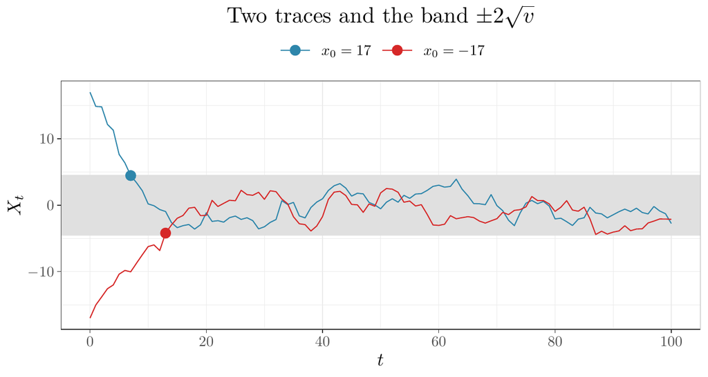

```r
set.seed(536)
start_labs <- c("$x_0 = 17$", "$x_0 = -17$")
df31 <- data.frame(t = rep(0:100, 2), x = c(trace_pos, trace_neg),
                   start = factor(rep(start_labs, each = 101),
                                  levels = start_labs))
df_enter <- data.frame(t = c(enter_pos, enter_neg),
                       x = c(trace_pos[enter_pos + 1],
                             trace_neg[enter_neg + 1]),
                       start = factor(start_labs, levels = start_labs))

p <- ggplot(df31, aes(t, x, color = start)) +
  annotate("rect", xmin = -Inf, xmax = Inf, ymin = -band, ymax = band,
           fill = "grey88") +
  geom_line(linewidth = 0.9) +
  geom_point(data = df_enter, size = 4) +
  scale_color_manual(values = unname(pal[c("blue", "red")]), name = NULL) +
  scale_x_continuous(breaks = int_breaks, labels = tex_num) +
  scale_y_continuous(labels = tex_num) +
  labs(title = r"(Two traces and the band $\pm 2\sqrt{v}$)",
       x = "$t$", y = "$X_t$") +
  tex_theme

knitr::include_graphics(tikz_png(p, "figures/lab09/ar1-traces.png",
                                 width = 9, height = 4.8))
```

```r
set.seed(536)
N <- 1e4
R <- 2000

dependence_row <- function(rho) {
  v <- 1 / (1 - rho^2)
  kappa <- (1 + rho) / (1 - rho)

  # one chain started from pi, keeping X_1, ..., X_N
  x <- simulate_ar1(rho, rnorm(1, 0, sqrt(v)), N)[-1]
  acf_hat <- acf(x, lag.max = 20, plot = FALSE)$acf[-1]
  ess_coda <- unname(coda::effectiveSize(x))

  # R chains side by side, keeping the running sum of each
  z <- rnorm(R, 0, sqrt(v))
  total <- numeric(R)
  for (t in 1:N) {
    z <- rho * z + rnorm(R)
    total <- total + z
  }
  Nvar <- N * var(total / N)

  list(row = data.frame(rho = rho, kappa = kappa,
                        ess_formula = N / kappa, ess_coda = ess_coda,
                        Nvar = Nvar, target = v * kappa,
                        se_Nvar = Nvar * sqrt(2 / (R - 1))),
       acf = acf_hat)
}

res_90 <- dependence_row(0.9)
res_m50 <- dependence_row(-0.5)

tab32 <- rbind(res_90$row, res_m50$row)
print(round(tab32, 3))

lags_show <- c(1, 2, 5, 10)
tab_acf <- rbind(sample_90 = res_90$acf[lags_show],
                 exact_90 = 0.9^lags_show,
                 sample_m50 = res_m50$acf[lags_show],
                 exact_m50 = (-0.5)^lags_show)
colnames(tab_acf) <- paste0("lag_", lags_show)
print(round(tab_acf, 3))
```

```
   rho  kappa ess_formula  ess_coda   Nvar  target se_Nvar
1  0.9 19.000     526.316   542.168 99.311 100.000   3.141
2 -0.5  0.333   30000.000 30009.312  0.455   0.444   0.014
            lag_1 lag_2  lag_5 lag_10
sample_90   0.901 0.808  0.582  0.342
exact_90    0.900 0.810  0.590  0.349
sample_m50 -0.500 0.254 -0.047  0.012
exact_m50  -0.500 0.250 -0.031  0.001
```

Run the figure chunk. The bars are the sample autocorrelations of the one chain. The points are $\rho^k$.

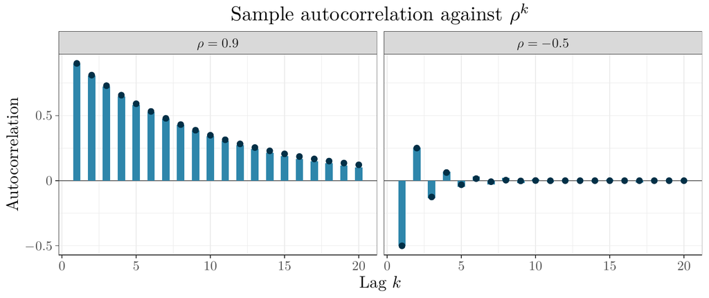

```r
set.seed(536)
lags <- 1:20
rho_labs <- c(r"($\rho = 0.9$)", r"($\rho = -0.5$)")
df32 <- data.frame(lag = rep(lags, 2),
                   sample = c(res_90$acf, res_m50$acf),
                   exact = c(0.9^lags, (-0.5)^lags),
                   rho = factor(rep(rho_labs, each = 20),
                                levels = rho_labs))

p <- ggplot(df32, aes(lag)) +
  geom_hline(yintercept = 0, color = pal[["grey"]]) +
  geom_col(aes(y = sample), fill = pal[["blue"]], width = 0.5) +
  geom_point(aes(y = exact), color = pal[["dark"]], size = 2.5) +
  facet_wrap(~ rho) +
  scale_x_continuous(breaks = int_breaks, labels = tex_num) +
  scale_y_continuous(labels = tex_num) +
  labs(title = r"(Sample autocorrelation against $\rho^k$)",
       x = "Lag $k$", y = "Autocorrelation") +
  tex_theme

knitr::include_graphics(tikz_png(p, "figures/lab09/ar1-acf.png",
                                 width = 10, height = 4.2))
```

**Report.**

1. $v$, $2\sqrt{v}$, and the first $t$ inside the band from each start, with the figure.
2. The table of $\rho$, $\kappa$, ESS by formula, ESS by `coda`, and $N\Var(\bar X_N)$, with its target and standard error.
3. The sample autocorrelations at lags 1, 2, 5, and 10, next to $\rho^k$, with the figure.
4. One sentence for each $\rho$ that quotes what $N = 10^4$ draws are worth.
5. Recall antithetic variates from week 4? One sentence that relates them to your row for $\rho = -0.5$.

We have $v = 5.263$ and $2\sqrt{v} = 4.588$. The chain from 17 first enters the band at $t = 7$, and the chain from $-17$ at $t = 13$. The mean $17(0.9)^t$ reaches the edge of the band at $t = 12.4$. Each chain has its own noise, so its first time inside the band moves around this value.

At $\rho = 0.9$ we have $\kappa = 19$. So $10^4$ draws are worth about 526 independent ones by the formula and 542 by `coda`. $N\Var(\bar X_N)$ is 99.3 with standard error 3.1, against $v\kappa = 100$.

At $\rho = -0.5$ we have $\kappa = 1/3$. So $10^4$ draws are worth about 30,000 independent ones by the formula and 30,009 by `coda`, above $N$. $N\Var(\bar X_N)$ is 0.455 with standard error 0.014, against $v\kappa = 0.444$. It is below $v = 1.333$, the value for independent draws.

Recall antithetic variates from week 4? A negative correlation within a pair made the average of the pair less variable than the average of two independent draws. Here each draw has correlation $-0.5$ with the one before it, and the same thing happens along the whole chain.

Over lags 1 to 20, the largest difference between the sample autocorrelations and $\rho^k$ is 0.019 at $\rho = 0.9$ and 0.020 at $\rho = -0.5$, so the sample autocorrelations follow $\rho^k$.

# Problem 2: Metropolis for $\Exp(1)$

We use the Metropolis algorithm.

**NoteMetropolis algorithm**

Target $\pi$, known up to a constant. Symmetric proposal $q(y \mid x) = q(x \mid y)$. Start $X_0$ with $\pi(X_0) > 0$. For $t = 0, 1, 2, \ldots$:

1. Draw $Y \sim q(\cdot \mid X_t)$.
2. Compute $\alpha(X_t, Y) = \min\bigl(1, \pi(Y)/\pi(X_t)\bigr)$.
3. Draw $U \sim \Uniform(0, 1)$.
4. Set $X_{t+1} = Y$ if $U \le \alpha(X_t, Y)$, otherwise $X_{t+1} = X_t$.

Theorem: this chain satisfies detailed balance with respect to $\pi$, and $\pi$ is stationary.

Our target is $\pi(x) = e^{-x}$, $x > 0$. The proposed value is $Y \sim \Normal(x, \sigma^2)$, with proposal standard deviation $\sigma$. For $y > 0$ we have $\alpha(x, y) = \min(1, e^{-(y - x)})$. For $y \le 0$ the target density is 0, so the proposal is rejected automatically. The acceptance rate is the fraction of proposals accepted. The proposal has positive density on all of $(0, \infty)$, so the chain is irreducible. A proposal $y \le 0$ has positive probability from every $x$, so the chain can stay put, and it is aperiodic. So $P(X_t \in A \mid X_0 = x) \to \pi(A)$ from every start $x > 0$, and $\bar h_N \to \E_\pi[h(X)]$ with probability one (Tierney, 1994). The target has an exponential tail, so the chain is geometrically ergodic (Mengersen and Tweedie, 1996), and the Markov chain CLT of Problem 1 applies. A burn-in is a first stretch we discard, and $B$ is the number of draws discarded.

1. Complete `metropolis_exp(N, sigma, x0)` below: the proposal, the acceptance probability, and the accept-or-stay step. It returns the chain $X_0, X_1, \ldots, X_N$ and the acceptance rate. Run it with $\sigma = 2$, $x_0 = 1$, and $N = 10^5$, and compute the mean and the variance of $X_1, \ldots, X_N$.
2. Run `metropolis_exp()` for 500 steps from $x_0 = 17$, and for 500 steps from $x_0 = 1$ for comparison, both with $\sigma = 2$. Find the first $t$ at which the chain from 17 is below 3. Choose a burn-in $B$ that you can defend. Compute the mean of the first 500 draws from 17, with all of them, and with the first $B$ discarded.
3. Run `metropolis_exp()` with $\sigma = 0.1$, $2$, and $17$, with $N = 10^5$ and $x_0 = 1$. For each $\sigma$, compute the acceptance rate, the ESS from `coda::effectiveSize()`, and the Monte Carlo standard error of the mean, $\text{sd}/\sqrt{\text{ESS}}$. Each run starts from `set.seed(536)`, so the row for $\sigma = 2$ is the chain of task 1.

```r
set.seed(536)
metropolis_exp <- function(N, sigma, x0) {
  x <- numeric(N + 1)
  x[1] <- x0
  accepted <- 0
  for (t in 1:N) {
    # the proposal
    y <- rnorm(1, x[t], sigma)
    # the acceptance probability, which is 0 when y <= 0
    alpha <- if (y > 0) min(1, exp(-(y - x[t]))) else 0
    # accept or stay
    if (runif(1) <= alpha) {
      x[t + 1] <- y
      accepted <- accepted + 1
    } else {
      x[t + 1] <- x[t]
    }
  }
  list(chain = x, accept_rate = accepted / N)
}

N <- 1e5
run <- metropolis_exp(N, sigma = 2, x0 = 1)
draws <- run$chain[-1]

print(sprintf("Acceptance rate: %.4f", run$accept_rate))
print(sprintf("Mean:            %.4f", mean(draws)))
print(sprintf("Variance:        %.4f", var(draws)))
```

```
[1] "Acceptance rate: 0.3363"
[1] "Mean:            0.9948"
[1] "Variance:        1.0033"
```

Run the figure chunk. The histogram is the $N$ draws. The curve is the target $e^{-x}$.

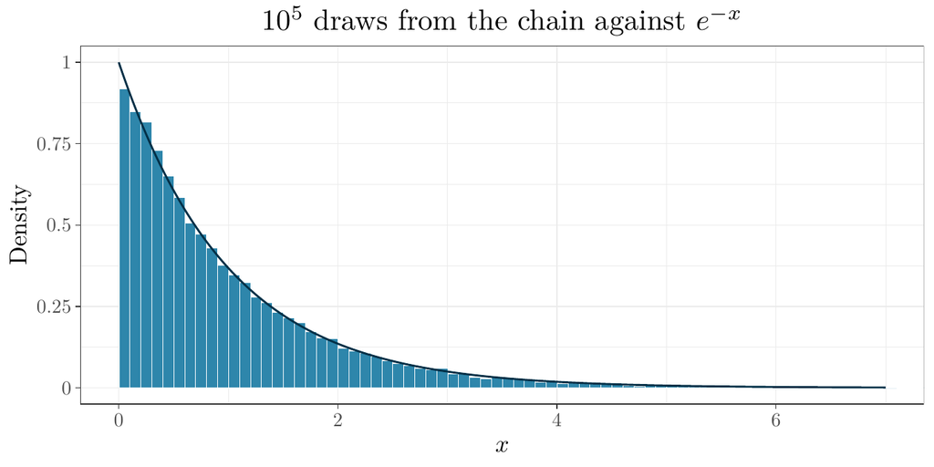

```r
set.seed(536)
xs <- seq(0, 7, length.out = 300)

p <- ggplot(data.frame(x = draws), aes(x)) +
  geom_histogram(aes(y = after_stat(density)), binwidth = 0.1,
                 boundary = 0, fill = pal[["blue"]], color = "white",
                 linewidth = 0.1) +
  geom_line(data = data.frame(x = xs, y = exp(-xs)), aes(x, y),
            color = pal[["dark"]], linewidth = 1.2) +
  coord_cartesian(xlim = c(0, 7)) +
  scale_x_continuous(labels = tex_num) +
  scale_y_continuous(labels = tex_num) +
  labs(title = "$10^5$ draws from the chain against $e^{-x}$",
       x = "$x$", y = "Density") +
  tex_theme

knitr::include_graphics(tikz_png(p, "figures/lab09/metropolis-hist.png",
                                 width = 9, height = 4.5))
```

```r
set.seed(536)
run_17 <- metropolis_exp(500, sigma = 2, x0 = 17)
run_1 <- metropolis_exp(500, sigma = 2, x0 = 1)

# the first t below 3; entry 1 of a chain is t = 0
first_below_3 <- min(which(run_17$chain < 3)) - 1
# the burn-in
B <- 100

# X_1, ..., X_500
draws_17 <- run_17$chain[-1]
mean_all <- mean(draws_17)
mean_after <- mean(draws_17[-(1:B)])

print(sprintf("First t below 3:       %d", first_below_3))
print(sprintf("Burn-in B:             %d", B))
print(sprintf("Mean of all 500 draws: %.4f", mean_all))
print(sprintf("Mean after discarding: %.4f", mean_after))
```

```
[1] "First t below 3:       28"
[1] "Burn-in B:             100"
[1] "Mean of all 500 draws: 1.2308"
[1] "Mean after discarding: 0.7898"
```

Run the figure chunk. It draws the first 200 steps of both chains. The dashed line is at 3, and the dotted line is your $B$.

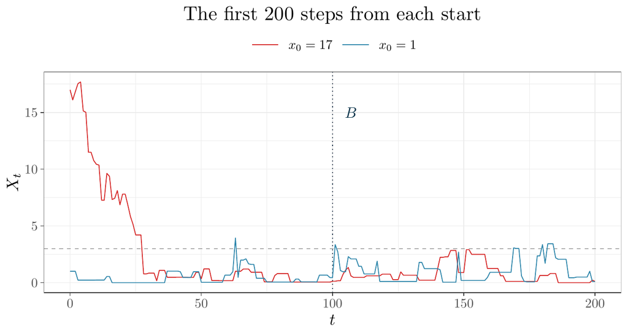

```r
set.seed(536)
start_labs <- c("$x_0 = 17$", "$x_0 = 1$")
df42 <- data.frame(t = rep(0:200, 2),
                   x = c(run_17$chain[1:201], run_1$chain[1:201]),
                   start = factor(rep(start_labs, each = 201),
                                  levels = start_labs))

p <- ggplot(df42, aes(t, x, color = start)) +
  geom_hline(yintercept = 3, linetype = "dashed", color = pal[["grey"]]) +
  geom_vline(xintercept = B, linetype = "dotted", color = pal[["dark"]],
             linewidth = 0.9) +
  geom_line(linewidth = 0.8) +
  annotate("text", x = B + 7, y = 15, label = "$B$",
           color = pal[["dark"]], size = 5.5) +
  scale_color_manual(values = unname(pal[c("red", "blue")]), name = NULL) +
  scale_x_continuous(breaks = int_breaks, labels = tex_num) +
  scale_y_continuous(labels = tex_num) +
  labs(title = "The first 200 steps from each start",
       x = "$t$", y = "$X_t$") +
  tex_theme

knitr::include_graphics(tikz_png(p, "figures/lab09/metropolis-burnin.png",
                                 width = 9, height = 4.8))
```

One run of 500 draws is noisy. To see what the burn-in does on average, the next code chunk repeats the run from 17 a thousand times. It is complete. Run it as is. It uses your $B$.

```r
set.seed(536)
R <- 1000
# one column per chain, X_0 in row 1
reps <- replicate(R, metropolis_exp(500, sigma = 2, x0 = 17)$chain)

first_t <- apply(reps, 2, function(z) min(which(z < 3)) - 1)
means_all <- colMeans(reps[-1, ])
means_after <- colMeans(reps[-(1:(B + 1)), ])

print(sprintf("Largest first t below 3: %d", max(first_t)))
print(sprintf("Average of means, all 500: %.3f (standard error %.3f)",
              mean(means_all), sd(means_all) / sqrt(R)))
print(sprintf("Average of means, after B: %.3f (standard error %.3f)",
              mean(means_after), sd(means_after) / sqrt(R)))
```

```
[1] "Largest first t below 3: 68"
[1] "Average of means, all 500: 1.423 (standard error 0.008)"
[1] "Average of means, after B: 0.992 (standard error 0.005)"
```

```r
set.seed(536)
sigmas <- c(0.1, 2, 17)
N <- 1e5
chains <- lapply(sigmas, function(s) {
  set.seed(536)
  metropolis_exp(N, sigma = s, x0 = 1)
})

accept <- sapply(chains, function(r) r$accept_rate)
# the ESS of X_1, ..., X_N, for each chain
ess <- sapply(chains, function(r) unname(coda::effectiveSize(r$chain[-1])))
sds <- sapply(chains, function(r) sd(r$chain[-1]))
# the Monte Carlo standard error of the mean
mcse <- sds / sqrt(ess)

tab43 <- data.frame(sigma = sigmas, accept = accept, ess = round(ess),
                    ess_ratio = ess / N, sd = sds, mcse = mcse)
print(round(tab43, 4))
```

```
  sigma accept  ess ess_ratio     sd   mcse
1   0.1 0.9256  195    0.0019 0.9384 0.0673
2   2.0 0.3363 9009    0.0901 1.0017 0.0106
3  17.0 0.0473 1959    0.0196 1.0436 0.0236
```

Run the figure chunk. It draws the first 2000 steps of each chain, on one vertical scale.

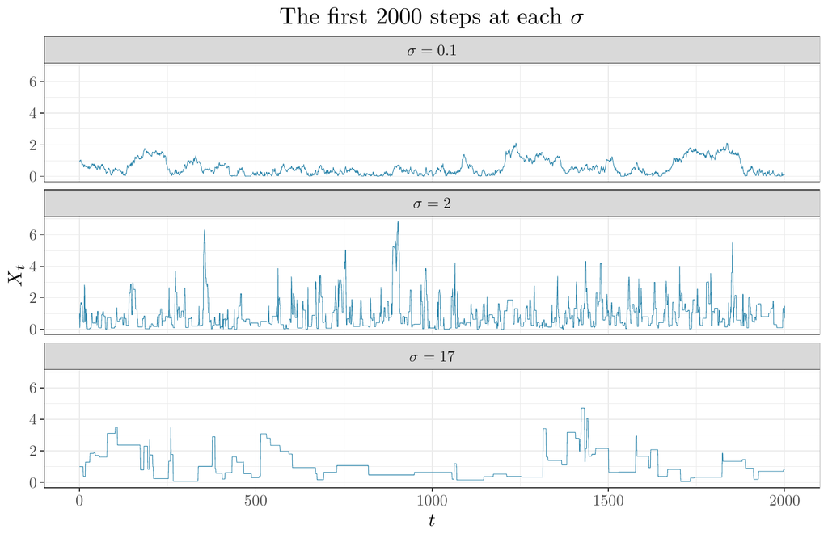

```r
set.seed(536)
steps <- 2000
sigma_labs <- sprintf("$\\sigma = %s$", sigmas)
first_steps <- lapply(chains, function(r) r$chain[1:(steps + 1)])
df43 <- data.frame(t = rep(0:steps, 3), x = unlist(first_steps),
                   sigma = factor(rep(sigma_labs, each = steps + 1),
                                  levels = sigma_labs))

p <- ggplot(df43, aes(t, x)) +
  geom_line(color = pal[["blue"]], linewidth = 0.4) +
  facet_wrap(~ sigma, ncol = 1) +
  scale_x_continuous(breaks = int_breaks, labels = tex_num) +
  scale_y_continuous(labels = tex_num) +
  labs(title = r"(The first 2000 steps at each $\sigma$)",
       x = "$t$", y = "$X_t$") +
  tex_theme

knitr::include_graphics(tikz_png(p, "figures/lab09/metropolis-scales.png",
                                 width = 10, height = 6.5))
```

**Report.**

1. The acceptance rate, and the mean and the variance next to the $\Exp(1)$ values, with the histogram.
2. The first $t$ below 3, and your $B$ with your reason, with the figure.
3. The mean of the first 500 draws, with and without discarding. From the 1000 chains: the largest first $t$ below 3, and the two averages with their standard errors.
4. One sentence that quotes these numbers and says what discarding changed.
5. The table of acceptance rate, ESS, and Monte Carlo standard error, with the figure.
6. One sentence that quotes your numbers, says which $\sigma$ gives the smallest standard error, and says how the acceptance rate and the standard error relate in your table.

The acceptance rate at $\sigma = 2$ is 0.3363. The mean is 0.9948 and the variance is 1.0033, against the $\Exp(1)$ values of 1 and 1. With Monte Carlo standard errors 0.0106 and 0.0349, they are 0.49 and 0.10 standard errors from 1.

From $x_0 = 17$, the first draw below 3 is at $t = 28$. Under the target, $P(X > 3) = e^{-3} = 0.050$, so 3 is about the 95th percentile of the target. We take $B = 100$, for two reasons.

- It is above 68, the largest first $t$ below 3 over the 1000 chains.
- The average of $X_{100}$ over the 1000 chains is 0.974, with standard error 0.031, against the target mean of 1.

In this run, the mean of all 500 draws is 1.231, and after discarding the first 100 it is 0.790. One short run is noisy, so the 1000 chains separate the bias from the noise. The average of the mean of all 500 draws is 1.423, with standard error 0.008. The average after discarding is 0.992, with standard error 0.005. Thus the start adds about 0.43 to the mean of 500 draws, and the burn-in removes it.

`effectiveSize()` fits an autoregression to the chain. At $\sigma = 0.1$ the sample autocorrelation is still 0.69 at lag 100, and that fit tends to miss such slow dependence. So read the ESS of that chain as a rough figure, and the true standard error as larger.

# Summary and Reflection

## Takeaways

1. **Dependence changes what $N$ draws are worth.** With $N = 10^4$, the ESS was about 526 at $\rho = 0.9$ and about 30,000 at $\rho = -0.5$.
2. **A burn-in removes the effect of the start.** Over 1000 chains of 500 draws from $x_0 = 17$, the average mean was 1.423 with all draws and 0.992 after discarding 100.
3. **Compare values of $\sigma$ by the standard error they give.** $\sigma = 2$ gave the smallest, 0.0106, at an acceptance rate of 0.336.

## Self-Assessment Questions

1. Show that $\kappa = (1 + \rho)/(1 - \rho)$ for AR(1), starting from $\rho_k = \rho^k$.
2. Explain how an ESS above $N$ is possible, using antithetic variates from week 4.
3. Explain what the acceptance rate of a Metropolis chain tells you, and what it leaves out.
4. Explain what a burn-in can fix, and what it cannot fix.